# Chapter 5

Emma Haapa

# Week 5: The Human Data

This week’s aim was to look at a joined dataset called the “human” data, which was joined from two separate datasets gii and hd in the data wrangling part of the exercise, and conduct a a Principal Component Analysis (PCA) on the data. The original datasets are [Human Development Index (HDI)](http://hdr.undp.org/en/composite/HDI) and [Gender Inequality Index (GII)](http://hdr.undp.org/en/composite/GII) of 2015 of the United Nations, which focus on the different factors associated with human development and gender inequality in different countries. The datasets were joined together using country as the identificating variable and only the observations associated with countries were left in the final dataset leaving out any observations relating to geographical area rather than a specific country. In this process, the variables that were deemed irrelevant with consideration to the following analysis, were excluded, resulting in a dataset that is further explored in the upcoming chapters. During the course of the data wrangling exercise, also two additional variables were coined by calculating a ratio of some of the already existing variables to get more information out of the existing data.

To get an initial peek at the dataset at hand, we use R’s glipse()-function.

```r
library(gmodels)
library(gdata)
library(dplyr) #accessed the dplyr-library
library(ggplot2) #accessed the ggplot2-library
library(readr) #accessed the readr-library
library(tidyr) #accessed tidyr-library
library(tidyverse)
library(corrplot)
library(GGally)
library(stringr)

human <- as.data.frame(read.table('human.csv'), sep="\t", header=TRUE)

glimpse(human)
```

```
## Observations: 155
## Variables: 8
## $ eduRatioFM    <dbl> 1.0072389, 0.9968288, 0.9834369, 0.9886128, 0.96...
## $ labRatioFM    <dbl> 0.8908297, 0.8189415, 0.8251001, 0.8840361, 0.82...
## $ YrsEduExp     <dbl> 17.5, 20.2, 15.8, 18.7, 17.9, 16.5, 18.6, 16.5, ...
## $ LifeExp       <dbl> 81.6, 82.4, 83.0, 80.2, 81.6, 80.9, 80.9, 79.1, ...
## $ GNIpercapita  <int> 64992, 42261, 56431, 44025, 45435, 43919, 39568,...
## $ MaternalMort  <int> 4, 6, 6, 5, 6, 7, 9, 28, 11, 8, 6, 4, 8, 4, 27, ...
## $ AdolBirth     <dbl> 7.8, 12.1, 1.9, 5.1, 6.2, 3.8, 8.2, 31.0, 14.5, ...
## $ RepParliament <dbl> 39.6, 30.5, 28.5, 38.0, 36.9, 36.9, 19.9, 19.4, ...
```

```r
summary(human)
```

```
##    eduRatioFM       labRatioFM       YrsEduExp        LifeExp
##  Min.   :0.1717   Min.   :0.1857   Min.   : 5.40   Min.   :49.00
##  1st Qu.:0.7264   1st Qu.:0.5984   1st Qu.:11.25   1st Qu.:66.30
##  Median :0.9375   Median :0.7535   Median :13.50   Median :74.20
##  Mean   :0.8529   Mean   :0.7074   Mean   :13.18   Mean   :71.65
##  3rd Qu.:0.9968   3rd Qu.:0.8535   3rd Qu.:15.20   3rd Qu.:77.25
##  Max.   :1.4967   Max.   :1.0380   Max.   :20.20   Max.   :83.50
##   GNIpercapita     MaternalMort      AdolBirth      RepParliament
##  Min.   :   581   Min.   :   1.0   Min.   :  0.60   Min.   : 0.00
##  1st Qu.:  4198   1st Qu.:  11.5   1st Qu.: 12.65   1st Qu.:12.40
##  Median : 12040   Median :  49.0   Median : 33.60   Median :19.30
##  Mean   : 17628   Mean   : 149.1   Mean   : 47.16   Mean   :20.91
##  3rd Qu.: 24512   3rd Qu.: 190.0   3rd Qu.: 71.95   3rd Qu.:27.95
##  Max.   :123124   Max.   :1100.0   Max.   :204.80   Max.   :57.50
```

Interpreting the above table, the dataset has eight variables and 155 observations (for 155 countries). The variables (renamed by myself in the data wrangling exercise) included in this dataset are:

eduRatioFM = Share of female population with secondary education / Share of male population with secondary education labRatioFM = Share of female population that participates in labour force / Share of male population that participates in labour force YrsEduExp = Expected years of education LifeExp = Life expectancy at birth GNIpercapita = Gross national income (GNI) per capita (dollars, purchasing power parity) MaternalMort = Maternal mortality rate AdolBirth = Adolescent birth rate RepParliament = Share of female representatives in the national parliament.

The summary of the dataset informs about the range of the variables, the median, quartiles and minimum and maximum values. By looking at the table it is clear to see that some of the max-values are extremely high compared to the median, which could indicate that there are some outliers or exceptional observations in the data.

The relationships between the variables in this dataset can be visualized by the ggpairs()-function, which demonstrates the scatter plots and correlation factors of the variables:

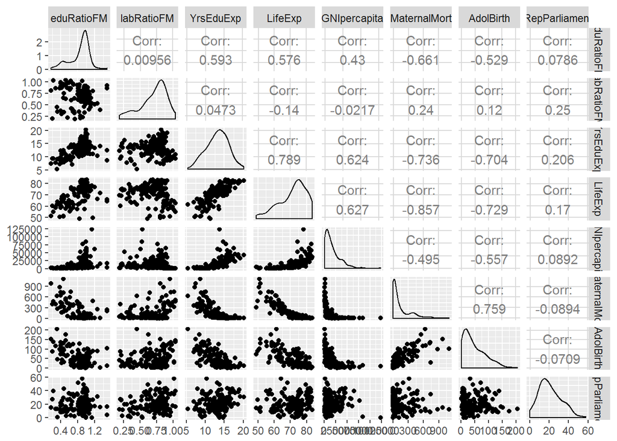

```r
ggpairs(human)
```

From the matrix above, it can be concluded that almost all of the variables’ distributions are relatively skewed, i.e. most of the values are in either end of the scale. However, for instance the gender ratio of population with secondary education and expected years in education variables seem to be quite close to being normally distributed, at least they peak in the middle of their range. It can also be noted that there indeed is significant correlation between different variables, going from -0,857 negatie correlation between Maternal mortality and Life expectancy up to 0,789 positive correlation between Life expectancy and Expected years of education. This, in turn, goes well together with the intuition one might have about the relationship between these particular variables: a high maternal mortality rate is in negative correlation with life expectancy, i.e. when maternal mortality increases, life expectancy in turn decreases, and when life expectancy increases, the positive correlation with expected years of education indicates that also the values of the YrsEduExp-variable increase (no causality indicated, of course). Also other values in this chart seem quite remarkable, but the anove table isn’t the most auspicious for the full interpretation of them, for which reason it is justifiable to draw a correlation matrix with visually helpful dots indicating the correlation between the variables and colours telling wether the correlation is positive or negative.

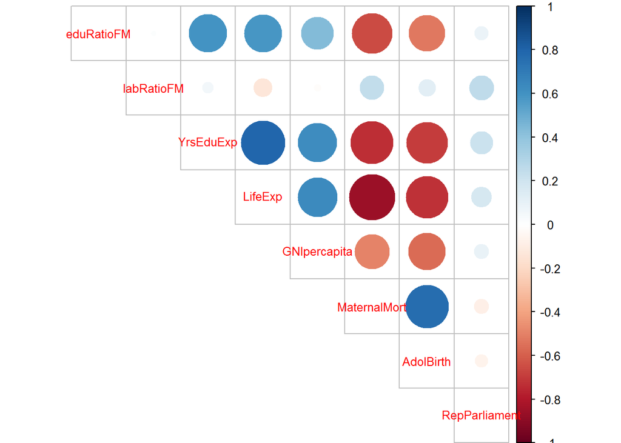

```r
corrplot(round(cor(human), digits = 2), method = "circle", type = "upper", tl.pos = "d", tl.cex = 0.8)
```

Now that the correlations can be determined by the colours and sizes of the dots in the matrix, it is easier to see which variables are in which kind of correlation with each other. Instantly we see that the aforementioned correlations (expected years of education with life expectancy, and maternal mortality with life expectancy) are the strongest: marked with big dark blue and dark red dots. Looking at this table it is also more clear to see that also maternal mortality and adolescent birth rate are in positive correlation, whereas expected years of education is in negatie correlation with both maternal mortality rate and adolescent birth. Also both expected years in education and life expectancy are in positive correlation with Gross national income per capita, which is quite intuitive.

## PCA of the Human data

A Principal Component Analysis (abbreviated as PCA) can be conducted on the dataset to lower its dimensionality using the singular value decomposition (SVD) method. According to instructions, it is first done on the non-standardised dataset for learning purposes: first we create a pca_human -object into which we save the PCA with prcomp()-function and then print the summary (s_nonst) of it.

```r
pca_human <- prcomp(human)
s_nonst <- summary(pca_human)
s_nonst
```

```
## Importance of components:
##                              PC1      PC2   PC3   PC4   PC5   PC6    PC7
## Standard deviation     1.854e+04 185.5219 25.19 11.45 3.766 1.566 0.1912
## Proportion of Variance 9.999e-01   0.0001  0.00  0.00 0.000 0.000 0.0000
## Cumulative Proportion  9.999e-01   1.0000  1.00  1.00 1.000 1.000 1.0000
##                           PC8
## Standard deviation     0.1591
## Proportion of Variance 0.0000
## Cumulative Proportion  1.0000
```

The problem with this initial approach without standardization is, as shown in the summary, that PC1 which is the first Principal Component, explains nearly all of the variance in contrast to the other PCs with significantly lower - essentially zero - proportions of variance. The plot of the precluding analysis is a bit strange and further indicates there is a problem with this approach:

[output not shown]

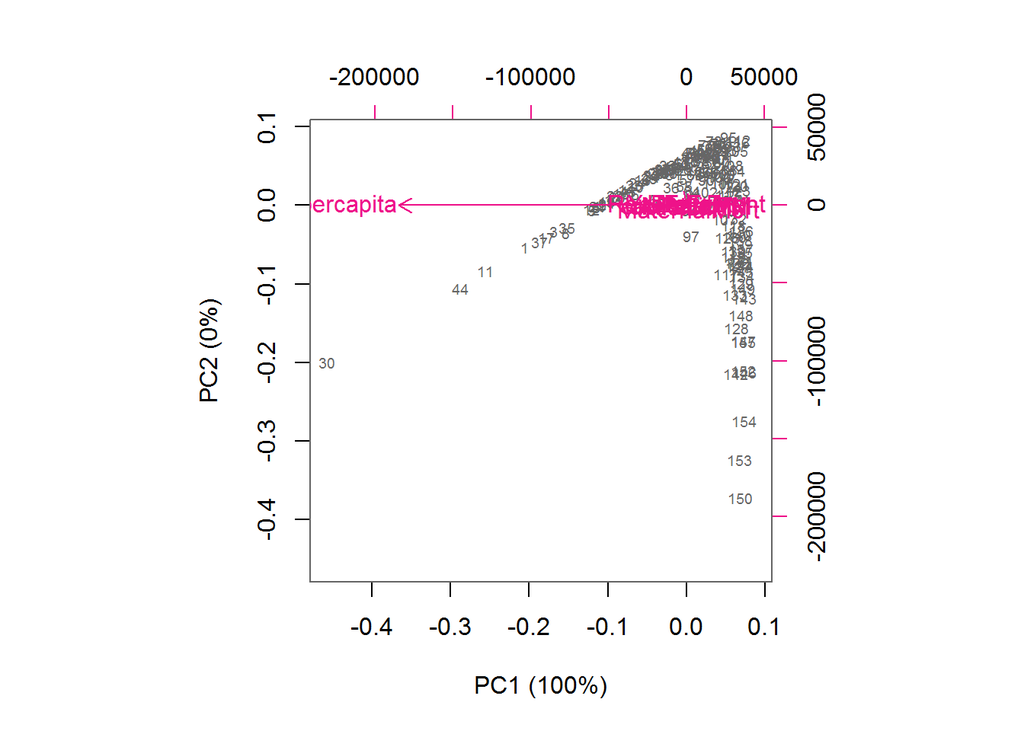

```r
pr_snonst <- round(100*s_nonst$importance[2, ], digits = 1)
pc_snonst_lab <- paste0(names(pr_snonst), " (", pr_snonst, "%)")
biplot(pca_human, choices = 1:2, cex = c(0.6, 1), col = c("grey40", "deeppink2"), xlab = pc_snonst_lab[1], ylab = pc_snonst_lab[2])
```

The picture is not very useful; in addition, there seems to be a problem drawing the arrows (according to the warning messages: “zero-length arrow is of indeterminate angle and so skipped”). Also the labels created from the percentages of variance are quite nonsensical - PC2(0%) and PC1(100%) which is true in this PCA but quite irrational for any kind of analysis. The result is indeed due to the skewed distributions of the variables - almost none of them were close to being normally distributed - so the differing variances led PCA to “think” that those variables with larger variance are also more important.

Because PCA is impacted by the scaling of the features, so, as instructed, it is more than useful to move on to use a different approach. By standardizing the dataset with the scale()-function used last week, we get the result that PCA can interpret more accordingly.

```r
human_st <- scale(human)
pca_st <- prcomp(human_st)
s_st <- summary(pca_st)
s_st
```

```
## Importance of components:
##                           PC1    PC2     PC3     PC4     PC5     PC6
## Standard deviation     2.0708 1.1397 0.87505 0.77886 0.66196 0.53631
## Proportion of Variance 0.5361 0.1624 0.09571 0.07583 0.05477 0.03595
## Cumulative Proportion  0.5361 0.6984 0.79413 0.86996 0.92473 0.96069
##                            PC7     PC8
## Standard deviation     0.45900 0.32224
## Proportion of Variance 0.02634 0.01298
## Cumulative Proportion  0.98702 1.00000
```

As we can see from the row of Proportion of Variance, the results diffr from the previous approach quite significantly. Now each of the PCAs explains some proportion of the variance - the first, PCA1, having the largest proportion of variance in this case, too - and none of the PCAs get a zero proportion. The rationality of this approach can be seen more efficiently by drawing the picture:

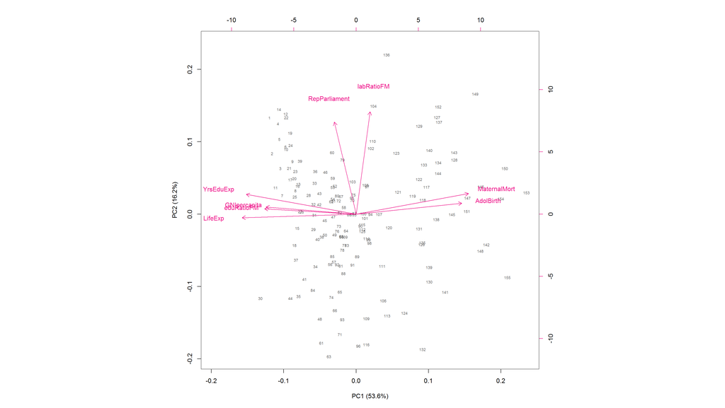

```r
pr_sst <- round(100*s_st$importance[2, ], digits = 1)
pc_sst_lab <- paste0(names(pr_sst), " (", pr_sst, "%)")
biplot(pca_st, choices = 1:2, cex = c(0.6, 1), col = c("grey40", "deeppink2"), xlab = pc_sst_lab[1], ylab = pc_sst_lab[2])
```

The proportions of variance as labels make more sense now, and there were no warnings regarding the drawing of the arrows. Also the picture looks clearer, the arrows are headed to different directions and the result seems interesting enough for some analysis to be executed.